# Thyroid Nodule Segmentation & Classification

## Overview

This notebook implements a two-stage deep learning pipeline for thyroid nodule analysis:

1. **Segmentation**: Attention U-Net identifies the nodule region
2. **Classification**: CNN classifies nodules as benign or malignant

## Key References

- **Attention U-Net**: Oktay et al. "Attention U-Net: Learning Where to Look for the Pancreas" ([arXiv:1804.03999](https://arxiv.org/abs/1804.03999))
- **U-Net**: Ronneberger et al. "U-Net: Convolutional Networks for Biomedical Image Segmentation" ([arXiv:1505.04597](https://arxiv.org/abs/1505.04597))
- **Mixup**: Zhang et al. "mixup: Beyond Empirical Risk Minimization" ([arXiv:1710.09412](https://arxiv.org/abs/1710.09412))
- **CutMix**: Yun et al. "CutMix: Regularization Strategy to Train Strong Classifiers" ([arXiv:1905.04899](https://arxiv.org/abs/1905.04899))

## Methodology

The pipeline addresses the challenge of limited labeled medical imaging data through:

- Pseudo-mask generation for weakly supervised segmentation
- Advanced data augmentation (Mixup/CutMix)
- K-fold cross-validation for robust evaluation

## 1. Environment Setup & Configuration

**Purpose**: Initialize the computational environment and define hyperparameters.

**Key configurations**:

- Image size: 224×224
- Batch size: 8
- Learning rate: 1e-5
- K-folds: 3

```python
import os
import gc
import cv2
import numpy as np
import matplotlib.pyplot as plt
import seaborn as sns
import tensorflow as tf
import pandas as pd
from tqdm.auto import tqdm

from sklearn.model_selection import StratifiedKFold
from sklearn.metrics import (
    confusion_matrix, accuracy_score, precision_score,
    recall_score, f1_score, roc_curve, auc
)
from sklearn.utils.class_weight import compute_class_weight

from tensorflow.keras.models import Model
from tensorflow.keras.layers import (
    Input, Conv2D, MaxPooling2D, UpSampling2D, concatenate,
    Dense, Dropout, BatchNormalization, GlobalAveragePooling2D,
    Multiply, Activation, Add
)
from tensorflow.keras.optimizers import Adam
from tensorflow.keras.callbacks import Callback, ModelCheckpoint, EarlyStopping, ReduceLROnPlateau

plt.rcParams['figure.dpi'] = 300
plt.rcParams['savefig.dpi'] = 300
sns.set_style("whitegrid")

# Reproducibility
SEED = 42
np.random.seed(SEED)
tf.random.set_seed(SEED)
os.environ["PYTHONHASHSEED"] = str(SEED)
os.environ["TF_DETERMINISTIC_OPS"] = "1"

CONFIG = {
    "img_size": (224, 224),
    "batch_size": 8,
    "unet_filters": 16,
    "unet_epochs": 30,
    "clf_epochs": 100,
    "learning_rate": 1e-5,
    "n_splits": 3,
    "target_ratio": 1.0,
    "seed": SEED,
}

SAVE_DIR = "./paper_results"
MODELS_DIR = os.path.join(SAVE_DIR, "models")
FIGURES_DIR = os.path.join(SAVE_DIR, "figures")

for dir_path in [SAVE_DIR, MODELS_DIR, FIGURES_DIR]:
    os.makedirs(dir_path, exist_ok=True)

print(f"TensorFlow version: {tf.__version__}")
print(f"GPU available: {tf.config.list_physical_devices('GPU')}")
```

[output not shown]

```
TensorFlow version: 2.20.0
GPU available: [PhysicalDevice(name='/physical_device:GPU:0', device_type='GPU')]
```

## 2. Data Loading & Preprocessing

**Purpose**: Load thyroid ultrasound images and extract labels from filenames.

**Pipeline**:

1. Parse filenames to extract benign/malignant labels
2. Load images and resize to 224×224
3. Normalize pixel values to [0, 1] range
4. Store metadata for tracking and analysis

```python
def parse_filename(fname):
    if not fname or not isinstance(fname, str):
        return None
    try:
        name = os.path.splitext(fname)[0]
        parts = name.split('_')
        if parts[-1].isdigit():
            cid = int(parts[-1])
            if 0 < cid < 6:
                return cid
        if parts[0].isdigit():
            cid = int(parts[0])
            if 0 < cid < 6:
                return cid
        return None
    except (ValueError, IndexError):
        return None


def augment_image(img):
    aug_img = img.copy()

    # Random horizontal flip
    if np.random.rand() > 0.5:
        aug_img = cv2.flip(aug_img, 1)

    # Random rotation (-15 to +15 degrees)
    angle = np.random.uniform(-15, 15)
    h, w = aug_img.shape[:2]
    rot_mat = cv2.getRotationMatrix2D((w//2, h//2), angle, 1.0)
    aug_img = cv2.warpAffine(aug_img, rot_mat, (w, h), borderMode=cv2.BORDER_REFLECT)

    # Slight brightness adjustment
    brightness = np.random.uniform(0.8, 1.2)
    aug_img = np.clip(aug_img * brightness, 0, 1).astype(np.float32)

    return aug_img


def load_dataset(image_dir, img_size):
    images, labels, filenames = [], [], []

    if not os.path.exists(image_dir):
        print(f"Error: Directory {image_dir} not found.")
        return np.array([]), np.array([]), []

    files = [f for f in os.listdir(image_dir) if parse_filename(f)]

    for fname in tqdm(files, desc="Loading images"):
        path = os.path.join(image_dir, fname)
        img = cv2.imread(path)
        if img is None:
            continue
        img = cv2.cvtColor(img, cv2.COLOR_BGR2RGB)
        img = cv2.resize(img, img_size)
        img = img.astype(np.float32) / 255.0

        class_id = parse_filename(fname)
        label = 1 if class_id >= 4 else 0

        # Add original image
        images.append(img)
        labels.append(label)
        filenames.append(fname)

        # Create 10 augmented copies for Class 5 (severe malignant)
        if class_id == 5:
            for i in range(10):
                aug_img = augment_image(img)
                images.append(aug_img)
                labels.append(label)
                filenames.append(f"{fname}_aug{i}")

    return np.array(images), np.array(labels), filenames
```

## 3. Dataset Verification

**Purpose**: Load the complete dataset and verify data integrity.

```python
# Load the full dataset
X, Y, fnames = load_dataset('./Thyroid_images', CONFIG['img_size'])
print(f"\nLoaded {len(X)} images")
print(f"  - Malignant (class 1): {np.sum(Y)}")
print(f"  - Benign (class 0): {len(Y) - np.sum(Y)}")
```

```
Loaded 490 images
  - Malignant (class 1): 14
  - Benign (class 0): 476
```

## 4. Pseudo-Mask Generation

Generate segmentation masks automatically when manual annotations are unavailable.

**Methodology** (based on classical computer vision):

1. **CLAHE** (Contrast Limited Adaptive Histogram Equalization): Enhances local contrast in ultrasound images
2. **Otsu's Thresholding**: Automatically determines optimal threshold for foreground/background separation
3. **Morphological Operations**: Clean up noise and fill holes in the mask

```python
def generate_pseudomasks(images):
    """Generate pseudo-masks using CLAHE + Otsu + morphological operations."""
    masks = []
    if len(images) == 0:
        return np.array([])

    for img in tqdm(images, desc="Generating pseudo-masks"):
        gray = cv2.cvtColor((img * 255).astype(np.uint8), cv2.COLOR_RGB2GRAY)
        clahe = cv2.createCLAHE(clipLimit=2.0, tileGridSize=(8, 8))
        gray = clahe.apply(gray)

        _, thresh = cv2.threshold(gray, 0, 255, cv2.THRESH_BINARY_INV + cv2.THRESH_OTSU)

        kernel = cv2.getStructuringElement(cv2.MORPH_ELLIPSE, (7, 7))
        thresh = cv2.morphologyEx(thresh, cv2.MORPH_OPEN, kernel, iterations=2)
        thresh = cv2.morphologyEx(thresh, cv2.MORPH_CLOSE, kernel, iterations=2)

        # Keep largest connected component
        num_labels, labels, stats, _ = cv2.connectedComponentsWithStats(thresh, connectivity=8)
        if num_labels > 1:
            areas = stats[1:, cv2.CC_STAT_AREA]
            largest_idx = np.argmax(areas) + 1
            mask = (labels == largest_idx).astype(np.uint8) * 255
        else:
            mask = np.zeros_like(gray)

        dist_transform = cv2.distanceTransform(mask, cv2.DIST_L2, 5)
        if dist_transform.max() > 0:
            _, mask = cv2.threshold(dist_transform, 0.3 * dist_transform.max(), 255, 0)
        mask = mask.astype(np.float32) / 255.0
        masks.append(mask[..., np.newaxis])

    return np.array(masks)


M = generate_pseudomasks(X)
```

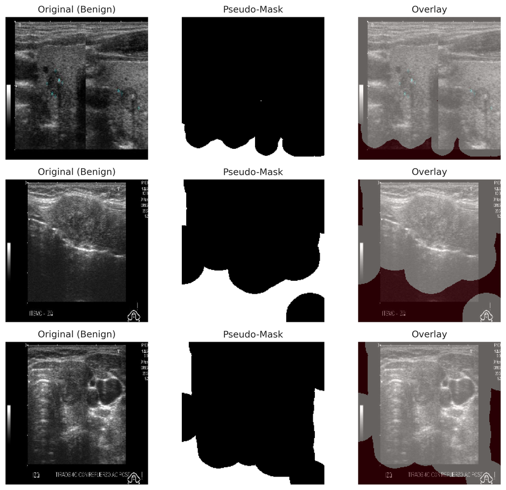

```python
def show_samples(images, masks, labels, n=3, save_path=None):
    """Display sample images with masks."""
    np.random.seed(42)
    indices = np.random.choice(len(images), min(n, len(images)), replace=False)

    fig, axes = plt.subplots(n, 3, figsize=(10, 3*n))
    if n == 1:
        axes = axes.reshape(1, -1)

    for i, idx in enumerate(indices):
        label_str = "Malignant" if labels[idx] == 1 else "Benign"

        axes[i, 0].imshow(images[idx])
        axes[i, 0].set_title(f"Original ({label_str})")
        axes[i, 0].axis('off')

        axes[i, 1].imshow(masks[idx].squeeze(), cmap='gray')
        axes[i, 1].set_title("Pseudo-Mask")
        axes[i, 1].axis('off')

        axes[i, 2].imshow(images[idx])
        axes[i, 2].imshow(masks[idx].squeeze(), alpha=0.4, cmap='Reds')
        axes[i, 2].set_title("Overlay")
        axes[i, 2].axis('off')

    plt.tight_layout()
    if save_path:
        plt.savefig(save_path, dpi=300, bbox_inches='tight')
    plt.show()


if len(X) > 0:
    show_samples(X, M, Y, n=3, save_path=os.path.join(FIGURES_DIR, "sample_images_masks.png"))
```

## 5. Data Augmentation: Mixup & CutMix

Artificially expand the training dataset and improve model generalization.

**Techniques**:

### CutMix ([Yun et al., 2019](https://arxiv.org/abs/1905.04899))

```python
class Augmentation:
    def __init__(self, seed=42):
        self.rng = np.random.RandomState(seed)

    def apply(self, img, mask):
        if len(mask.shape) == 3:
            mask = mask.squeeze()

        # Horizontal flip
        if self.rng.rand() > 0.5:
            img, mask = np.fliplr(img), np.fliplr(mask)

        # Vertical flip
        if self.rng.rand() > 0.5:
            img, mask = np.flipud(img), np.flipud(mask)

        # Rotation
        if self.rng.rand() > 0.5:
            angle = self.rng.uniform(-90, 90)
            h, w = img.shape[:2]
            M_rot = cv2.getRotationMatrix2D((w//2, h//2), angle, 1.0)
            img = cv2.warpAffine(img, M_rot, (w, h), borderMode=cv2.BORDER_REFLECT)
            mask = cv2.warpAffine(mask, M_rot, (w, h), borderMode=cv2.BORDER_REFLECT)

        # Elastic deformation
        if self.rng.rand() > 0.3:
            h, w = img.shape[:2]
            alpha, sigma = 10, 3
            dx = cv2.GaussianBlur((self.rng.rand(h, w) * 2 - 1), (0, 0), sigma) * alpha
            dy = cv2.GaussianBlur((self.rng.rand(h, w) * 2 - 1), (0, 0), sigma) * alpha
            x, y = np.meshgrid(np.arange(w), np.arange(h))
            map_x, map_y = (x + dx).astype(np.float32), (y + dy).astype(np.float32)
            img = cv2.remap(img, map_x, map_y, cv2.INTER_LINEAR, borderMode=cv2.BORDER_REFLECT)
            mask = cv2.remap(mask, map_x, map_y, cv2.INTER_NEAREST, borderMode=cv2.BORDER_REFLECT)

        # Brightness/contrast
        if self.rng.rand() > 0.5:
            alpha = self.rng.uniform(0.7, 1.3)
            beta = self.rng.uniform(-20, 20)
            img = np.clip(alpha * img * 255 + beta, 0, 255).astype(np.uint8) / 255.0

        mask = (mask > 0.5).astype(np.float32)
        return img, mask[..., np.newaxis]


augmenter = Augmentation(seed=SEED)
```

```python
def mixup_images(X1, M1, X2, M2, alpha=0.4):
    lam = np.random.beta(alpha, alpha)
    mixed_img = lam * X1 + (1 - lam) * X2
    mixed_img = np.clip(mixed_img, 0, 1)
    mixed_mask = lam * M1 + (1 - lam) * M2
    mixed_mask = (mixed_mask > 0.5).astype(np.float32)
    return mixed_img, mixed_mask


def cutmix_images(X1, M1, X2, M2):
    h, w = X1.shape[:2]
    lam = np.random.uniform(0.3, 0.7)
    cut_ratio = np.sqrt(1 - lam)
    cut_h, cut_w = int(h * cut_ratio), int(w * cut_ratio)

    cx, cy = np.random.randint(w), np.random.randint(h)
    bbx1 = np.clip(cx - cut_w // 2, 0, w)
    bby1 = np.clip(cy - cut_h // 2, 0, h)
    bbx2 = np.clip(cx + cut_w // 2, 0, w)
    bby2 = np.clip(cy + cut_h // 2, 0, h)

    cutmix_img = X1.copy()
    cutmix_img[bby1:bby2, bbx1:bbx2] = X2[bby1:bby2, bbx1:bbx2]

    cutmix_mask = M1.copy()
    if len(M1.shape) == 3:
        cutmix_mask[bby1:bby2, bbx1:bbx2, :] = M2[bby1:bby2, bbx1:bbx2, :]
    else:
        cutmix_mask[bby1:bby2, bbx1:bbx2] = M2[bby1:bby2, bbx1:bbx2]

    return cutmix_img, (cutmix_mask > 0.5).astype(np.float32)


def advanced_synthetic_augmentation(X, M, Y, augmenter, target_ratio=1.0):
    """Balance dataset using Mixup/CutMix for minority class."""
    if len(Y) == 0:
        return X, M, Y

    classes, counts = np.unique(Y, return_counts=True)
    if len(classes) < 2:
        return X, M, Y

    maj_class = classes[np.argmax(counts)]
    min_class = classes[np.argmin(counts)]

    X_maj, M_maj, Y_maj = X[Y == maj_class], M[Y == maj_class], Y[Y == maj_class]
    X_min, M_min, Y_min = X[Y == min_class], M[Y == min_class], Y[Y == min_class]

    n_needed = int(len(X_maj) * target_ratio) - len(X_min)
    if n_needed <= 0:
        return X, M, Y

    syn_imgs, syn_masks, syn_labels = [], [], []

    for _ in range(n_needed):
        idx1, idx2 = np.random.choice(len(X_min), 2, replace=True)
        img1, mask1 = X_min[idx1].copy(), M_min[idx1].copy()
        img2, mask2 = X_min[idx2].copy(), M_min[idx2].copy()

        if len(mask1.shape) == 3: mask1 = mask1.squeeze()
        if len(mask2.shape) == 3: mask2 = mask2.squeeze()

        if np.random.rand() < 0.5:
            s_img, s_mask = mixup_images(img1, mask1, img2, mask2)
        else:
            s_img, s_mask = cutmix_images(img1, mask1, img2, mask2)

        s_img, s_mask = augmenter.apply(s_img, s_mask)

        syn_imgs.append(s_img)
        syn_masks.append(s_mask)
        syn_labels.append(min_class)

    X_bal = np.concatenate([X_maj, X_min, np.array(syn_imgs)])
    M_bal = np.concatenate([M_maj, M_min, np.array(syn_masks)])
    Y_bal = np.concatenate([Y_maj, Y_min, np.array(syn_labels)])

    p = np.random.permutation(len(X_bal))
    return X_bal[p], M_bal[p], Y_bal[p]
```

## 6. Model Architectures

Define neural network architectures for segmentation and classification.

### Attention U-Net (Segmentation)

**Why Attention U-Net**:

- Standard U-Net ([Ronneberger et al., 2015](https://arxiv.org/abs/1505.04597)) is the gold standard for medical image segmentation
- Attention gates ([Oktay et al., 2018](https://arxiv.org/abs/1804.03999)) improve focus on relevant regions
- Particularly effective for small target regions (like thyroid nodules)

**Architecture**:

1. **Encoder**: Progressively downsamples to extract hierarchical features
2. **Bottleneck**: Captures global context at lowest resolution
3. **Decoder**: Upsamples while incorporating skip connections
4. **Attention Gates**: Weight skip connections based on relevance

### Classification CNN

**Purpose**: Classify extracted ROI (Region of Interest) as benign/malignant.

**Architecture**:

- Convolutional blocks for feature extraction
- Global Average Pooling
- Dense layers for classification
- Sigmoid activation for binary classification

```python
def build_attention_unet(input_shape=(224, 224, 3), filters=32):
    """Attention U-Net for segmentation."""
    def conv_block(x, f):
        x = Conv2D(f, 3, padding="same", activation="relu")(x)
        x = BatchNormalization()(x)
        x = Conv2D(f, 3, padding="same", activation="relu")(x)
        return BatchNormalization()(x)

    def attention_gate(x, g, f):
        theta = Conv2D(f, 1, padding="same")(x)
        phi = Conv2D(f, 1, padding="same")(g)
        psi = Activation("relu")(Add()([theta, phi]))
        psi = Conv2D(1, 1, padding="same", activation="sigmoid")(psi)
        return Multiply()([x, psi])

    inputs = Input(input_shape)

    # Encoder
    c1 = conv_block(inputs, filters)
    p1 = MaxPooling2D(2)(c1)
    c2 = conv_block(p1, filters*2)
    p2 = MaxPooling2D(2)(c2)
    c3 = conv_block(p2, filters*4)
    p3 = MaxPooling2D(2)(c3)

    # Bottleneck
    c4 = conv_block(p3, filters*8)

    # Decoder with attention
    u5 = UpSampling2D(2)(c4)
    att5 = attention_gate(c3, u5, filters*4)
    c5 = conv_block(concatenate([u5, att5]), filters*4)

    u6 = UpSampling2D(2)(c5)
    att6 = attention_gate(c2, u6, filters*2)
    c6 = conv_block(concatenate([u6, att6]), filters*2)

    u7 = UpSampling2D(2)(c6)
    att7 = attention_gate(c1, u7, filters)
    c7 = conv_block(concatenate([u7, att7]), filters)

    outputs = Conv2D(1, 1, activation="sigmoid")(c7)

    return Model(inputs, outputs, name="Attention_UNet")


def build_classifier_cnn(input_shape=(224, 224, 3)):
    """CNN classifier with BatchNormalization for better feature learning."""
    inputs = Input(input_shape)

    x = Conv2D(32, 3, padding='same')(inputs)
    x = BatchNormalization()(x)
    x = Activation('relu')(x)
    x = MaxPooling2D(2)(x)

    x = Conv2D(64, 3, padding='same')(x)
    x = BatchNormalization()(x)
    x = Activation('relu')(x)
    x = MaxPooling2D(2)(x)

    x = Conv2D(128, 3, padding='same')(x)
    x = BatchNormalization()(x)
    x = Activation('relu')(x)
    x = GlobalAveragePooling2D()(x)

    x = Dense(128)(x)
    x = BatchNormalization()(x)
    x = Activation('relu')(x)
    x = Dropout(0.5)(x)
    outputs = Dense(1, activation='sigmoid')(x)

    return Model(inputs, outputs, name="CNN_Classifier")
```

## 7. ROI Extraction

Extract the Region of Interest (nodule area) from segmentation masks.

**Process**:

1. Find bounding box coordinates from segmentation mask
2. Add margin (10% default) to capture surrounding context
3. Crop original image to ROI
4. Resize to standard input size for classifier

```python
def extract_rois(images, masks, margin=0.1):
    """Extract ROIs based on mask bounding boxes."""
    rois = []
    for img, mask in zip(images, masks):
        mask_sq = mask.squeeze()

        if np.sum(mask_sq) > 0:
            rows = np.any(mask_sq, axis=1)
            cols = np.any(mask_sq, axis=0)

            row_indices = np.where(rows)[0]
            col_indices = np.where(cols)[0]

            if len(row_indices) > 0 and len(col_indices) > 0:
                rmin, rmax = row_indices[[0, -1]]
                cmin, cmax = col_indices[[0, -1]]

                h, w = img.shape[:2]
                margin_h, margin_w = int(margin * h), int(margin * w)

                rmin = max(0, rmin - margin_h)
                rmax = min(h, rmax + margin_h)
                cmin = max(0, cmin - margin_w)
                cmax = min(w, cmax + margin_w)

                if rmax > rmin and cmax > cmin:
                    roi = img[rmin:rmax, cmin:cmax]
                    roi = cv2.resize(roi, CONFIG["img_size"])
                else:
                    roi = cv2.resize(img, CONFIG["img_size"])
            else:
                roi = cv2.resize(img, CONFIG["img_size"])
        else:
            roi = cv2.resize(img, CONFIG["img_size"])

        rois.append(roi)

    return np.array(rois)
```

## 8. Training with K-Fold Cross-Validation

Train and evaluate models using stratified K-fold cross-validation.

**Why K-Fold CV**:

- Small medical datasets require robust evaluation
- Every sample serves as both training and validation data
- Reduces variance in performance estimates
- Stratified splits preserve class distribution in each fold

**Training Pipeline**:

### Stage 2: Classification (CNN)

**Callbacks**:

- Early stopping: Prevents overfitting
- ReduceLROnPlateau: Adaptive learning rate
- ModelCheckpoint: Save best model per fold

```python
class TQDMProgressBar(Callback):
    def __init__(self, num_epochs, desc="Training"):
        super().__init__()
        self.num_epochs = num_epochs
        self.desc = desc
        self.bar = None

    def on_train_begin(self, logs=None):
        self.bar = tqdm(total=self.num_epochs, desc=self.desc, unit="epoch")

    def on_epoch_end(self, epoch, logs=None):
        logs = logs or {}
        postfix = {k: f"{v:.4f}" for k, v in logs.items() if 'val_' not in k}
        self.bar.set_postfix(postfix)
        self.bar.update(1)

    def on_train_end(self, logs=None):
        if self.bar:
            self.bar.close()


def plot_training_curves(history, title_prefix="", save_path=None):
    fig, axes = plt.subplots(1, 2, figsize=(12, 4))

    epochs = range(1, len(history.history['loss']) + 1)

    axes[0].plot(epochs, history.history['loss'], 'b-', label='Train Loss')
    if 'val_loss' in history.history:
        axes[0].plot(epochs, history.history['val_loss'], 'r--', label='Val Loss')
    axes[0].set_xlabel('Epoch')
    axes[0].set_ylabel('Loss')
    axes[0].set_title(f'{title_prefix} Loss')
    axes[0].legend()
    axes[0].grid(True, alpha=0.3)

    axes[1].plot(epochs, history.history['accuracy'], 'b-', label='Train Acc')
    if 'val_accuracy' in history.history:
        axes[1].plot(epochs, history.history['val_accuracy'], 'r--', label='Val Acc')
    axes[1].set_xlabel('Epoch')
    axes[1].set_ylabel('Accuracy')
    axes[1].set_title(f'{title_prefix} Accuracy')
    axes[1].legend()
    axes[1].grid(True, alpha=0.3)

    plt.tight_layout()
    if save_path:
        plt.savefig(save_path, dpi=300, bbox_inches='tight')
    plt.show()
```

```
Starting 3-fold CV  |  Fixed threshold = 0.5
Total: 490 | Malignant: 14 | Benign: 476

============================================================
  Fold 1/3
============================================================
```

```
Train: 326 | Val: 164
  Val Malignant: 5 | Val Benign: 159
Class weights: benign=0.51, malignant=18.11
After balancing: 634 samples

Training U-Net...
```

[output not shown]

[output not shown]

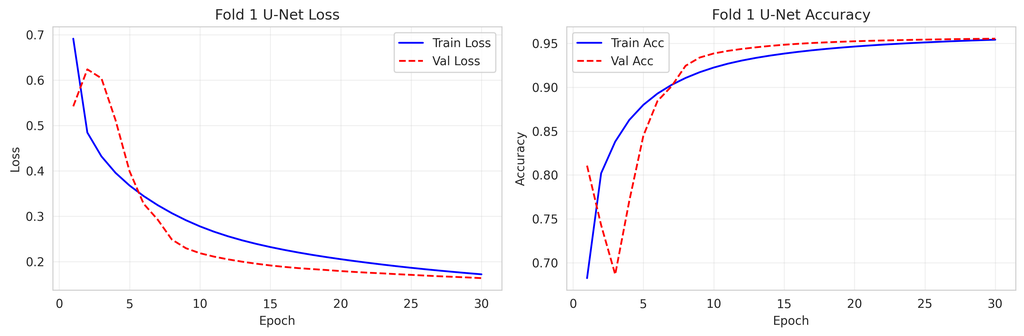

[output not shown]

```
Training Classifier...
```

[output not shown]

```
Epoch 7: ReduceLROnPlateau reducing learning rate to 4.999999873689376e-06.

Epoch 17: ReduceLROnPlateau reducing learning rate to 2.499999936844688e-06.

Epoch 22: ReduceLROnPlateau reducing learning rate to 1.249999968422344e-06.
```

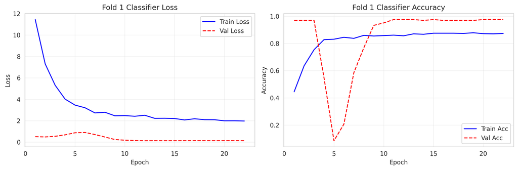

[output not shown]

```
--- Fold 1 Confusion Metrics (threshold=0.5) ---
  Confusion Matrix:
                 Predicted
                 Benign  Malignant
  Actual Benign     158        1
  Actual Malig.       3        2

  TP=2  TN=158  FP=1  FN=3
  Accuracy:    0.9756
  Sensitivity: 0.4000  (recall / TPR)
  Specificity: 0.9937  (TNR)
  Precision:   0.6667  (PPV)
  F1-Score:    0.5000
  AUC:         0.7138
```

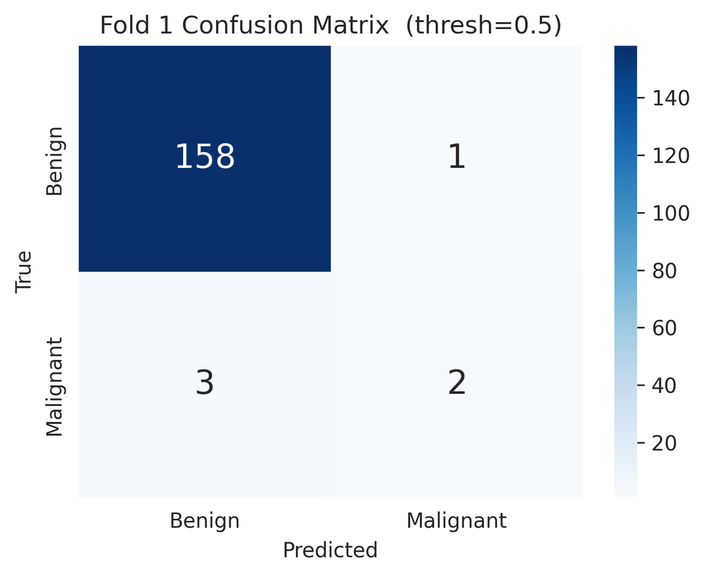

```
============================================================
  Fold 2/3
============================================================
Train: 327 | Val: 163
  Val Malignant: 4 | Val Benign: 159
Class weights: benign=0.52, malignant=16.35
After balancing: 634 samples

Training U-Net...
```

[output not shown]

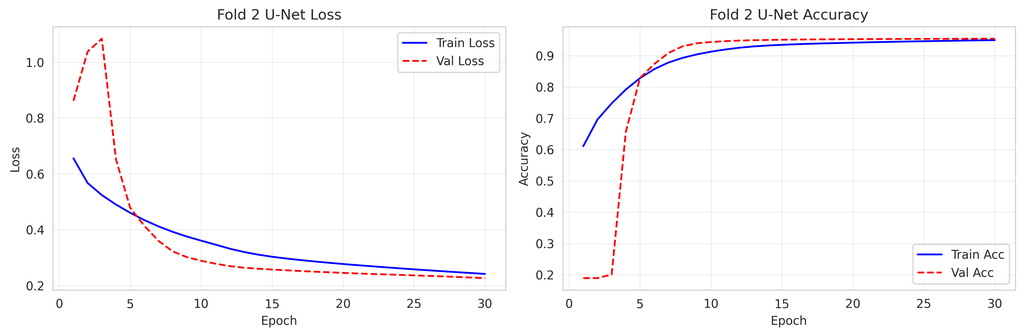

[output not shown]

[output not shown]

[output not shown]

```
Epoch 6: ReduceLROnPlateau reducing learning rate to 4.999999873689376e-06.

Epoch 23: ReduceLROnPlateau reducing learning rate to 2.499999936844688e-06.

Epoch 28: ReduceLROnPlateau reducing learning rate to 1.249999968422344e-06.
```

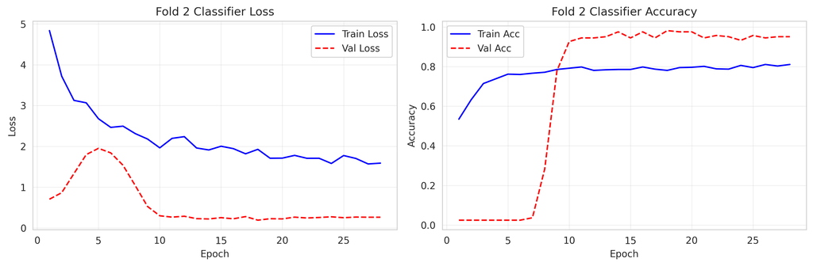

[output not shown]

[output not shown]

```
--- Fold 2 Confusion Metrics (threshold=0.5) ---
  Confusion Matrix:
                 Predicted
                 Benign  Malignant
  Actual Benign     157        2
  Actual Malig.       1        3

  TP=3  TN=157  FP=2  FN=1
  Accuracy:    0.9816
  Sensitivity: 0.7500  (recall / TPR)
  Specificity: 0.9874  (TNR)
  Precision:   0.6000  (PPV)
  F1-Score:    0.6667
  AUC:         0.9277
```

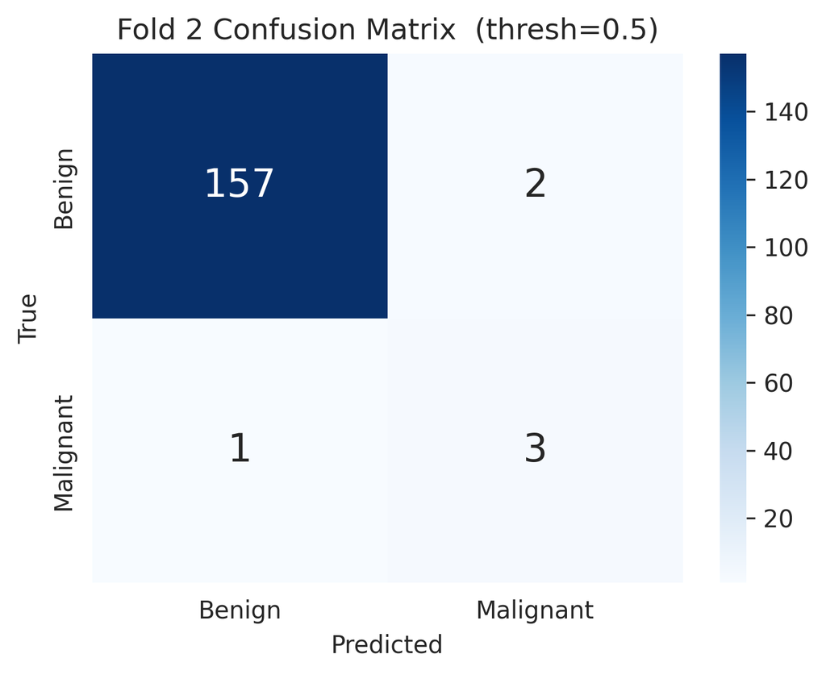

```
============================================================
  Fold 3/3
============================================================
Train: 327 | Val: 163
  Val Malignant: 5 | Val Benign: 158
Class weights: benign=0.51, malignant=18.17
After balancing: 636 samples

Training U-Net...
```

[output not shown]

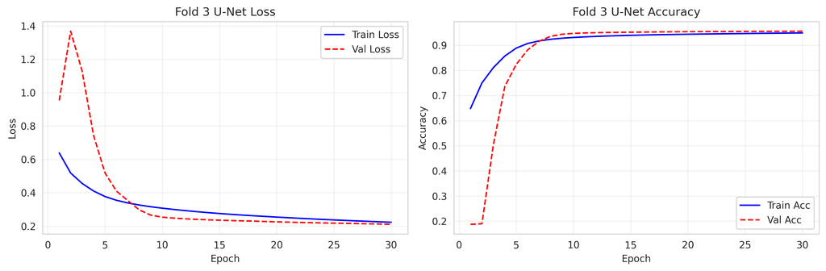

[output not shown]

```
Training Classifier...
```

[output not shown]

```
Epoch 6: ReduceLROnPlateau reducing learning rate to 4.999999873689376e-06.

Epoch 21: ReduceLROnPlateau reducing learning rate to 2.499999936844688e-06.

Epoch 26: ReduceLROnPlateau reducing learning rate to 1.249999968422344e-06.
```

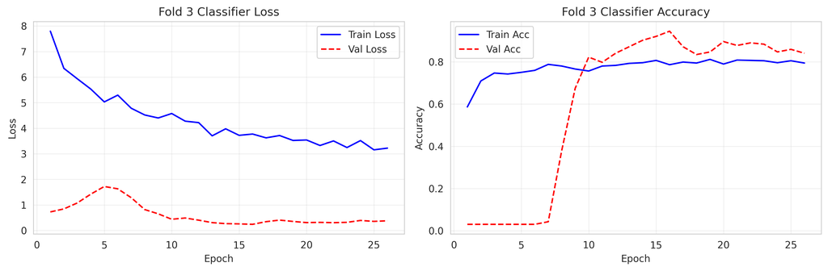

[output not shown]

```
--- Fold 3 Confusion Metrics (threshold=0.5) ---
  Confusion Matrix:
                 Predicted
                 Benign  Malignant
  Actual Benign     151        7
  Actual Malig.       2        3

  TP=3  TN=151  FP=7  FN=2
  Accuracy:    0.9448
  Sensitivity: 0.6000  (recall / TPR)
  Specificity: 0.9557  (TNR)
  Precision:   0.3000  (PPV)
  F1-Score:    0.4000
  AUC:         0.9506
```

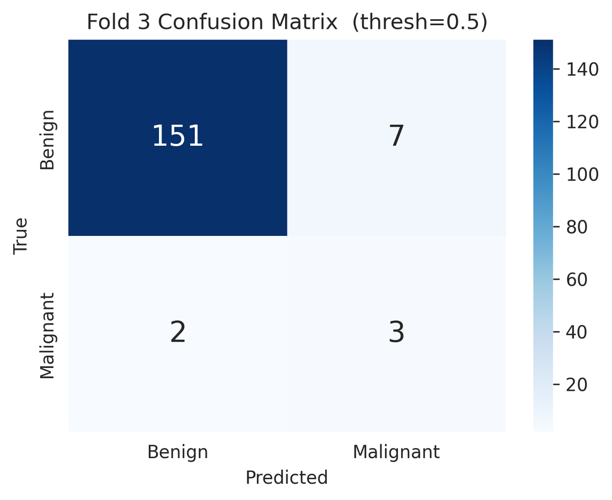

```python
if len(X) == 0:
    raise ValueError("No images found! Check the Thyroid_images directory.")

FIXED_THRESHOLD = 0.5

skf = StratifiedKFold(n_splits=CONFIG['n_splits'], shuffle=True, random_state=SEED)
fold_metrics = []
fold_cms = []
all_histories = {'unet': [], 'clf': []}

print(f"Starting {CONFIG['n_splits']}-fold CV  |  Fixed threshold = {FIXED_THRESHOLD}")
print(f"Total: {len(X)} | Malignant: {np.sum(Y)} | Benign: {len(Y) - np.sum(Y)}")

for fold, (train_idx, val_idx) in enumerate(skf.split(X, Y)):
    print(f"\n{'='*60}")
    print(f"  Fold {fold+1}/{CONFIG['n_splits']}")
    print(f"{'='*60}")

    # Clear session to free memory from previous fold
    tf.keras.backend.clear_session()
    gc.collect()

    X_train, X_val = X[train_idx], X[val_idx]
    M_train, M_val = M[train_idx], M[val_idx]
    Y_train, Y_val = Y[train_idx], Y[val_idx]

    print(f"Train: {len(X_train)} | Val: {len(X_val)}")
    print(f"  Val Malignant: {np.sum(Y_val)} | Val Benign: {len(Y_val) - np.sum(Y_val)}")

    # Compute class weights BEFORE balancing (on original imbalanced data)
    cw = compute_class_weight('balanced', classes=np.array([0, 1]), y=Y_train)
    class_weights = {0: cw[0], 1: cw[1]}
    print(f"Class weights: benign={cw[0]:.2f}, malignant={cw[1]:.2f}")

    # Balance training set
    X_train_bal, M_train_bal, Y_train_bal = advanced_synthetic_augmentation(
        X_train, M_train, Y_train, augmenter, target_ratio=CONFIG['target_ratio']
    )
    print(f"After balancing: {len(X_train_bal)} samples")

    # Stage 1: U-Net
    print("\nTraining U-Net...")
    unet = build_attention_unet(filters=CONFIG['unet_filters'])
    unet.compile(optimizer=Adam(CONFIG['learning_rate']), loss='binary_crossentropy', metrics=['accuracy'])

    unet_checkpoint = ModelCheckpoint(
        filepath=os.path.join(MODELS_DIR, f'unet_fold_{fold+1}_best.keras'),
        monitor='val_loss', save_best_only=True, verbose=0
    )
    unet_early_stop = EarlyStopping(monitor='val_loss', patience=10, restore_best_weights=True)
    unet_reduce_lr = ReduceLROnPlateau(monitor='val_loss', factor=0.5, patience=5, verbose=1)
    unet_pbar = TQDMProgressBar(CONFIG['unet_epochs'], desc=f"Fold {fold+1} U-Net")

    unet_history = unet.fit(
        X_train_bal, M_train_bal,
        batch_size=CONFIG['batch_size'],
        epochs=CONFIG['unet_epochs'],
        verbose=0,
        validation_data=(X_val, M_val),
        callbacks=[unet_pbar, unet_checkpoint, unet_early_stop, unet_reduce_lr]
    )
    all_histories['unet'].append(unet_history)

    plot_training_curves(unet_history, f"Fold {fold+1} U-Net",
                        save_path=os.path.join(FIGURES_DIR, f'fold_{fold+1}_unet_training.png'))

    # Predict masks and free U-Net memory before classifier
    M_val_pred = unet.predict(X_val, verbose=0)
    M_val_pred = (M_val_pred > 0.5).astype(np.float32)
    del unet
    gc.collect()

    # Stage 2: Classifier
    print("\nTraining Classifier...")
    X_train_roi = extract_rois(X_train_bal, M_train_bal)
    X_val_roi = extract_rois(X_val, M_val_pred)

    clf = build_classifier_cnn()
    clf.compile(optimizer=Adam(CONFIG['learning_rate']), loss='binary_crossentropy', metrics=['accuracy'])

    clf_checkpoint = ModelCheckpoint(
        filepath=os.path.join(MODELS_DIR, f'clf_fold_{fold+1}_best.keras'),
        monitor='val_loss', save_best_only=True, verbose=0
    )
    clf_early_stop = EarlyStopping(monitor='val_loss', patience=10, restore_best_weights=True)
    clf_reduce_lr = ReduceLROnPlateau(monitor='val_loss', factor=0.5, patience=5, verbose=1)
    clf_pbar = TQDMProgressBar(CONFIG['clf_epochs'], desc=f"Fold {fold+1} Classifier")

    clf_history = clf.fit(
        X_train_roi, Y_train_bal,
        batch_size=CONFIG['batch_size'],
        epochs=CONFIG['clf_epochs'],
        verbose=0,
        validation_data=(X_val_roi, Y_val),
        class_weight=class_weights,
        callbacks=[clf_pbar, clf_checkpoint, clf_early_stop, clf_reduce_lr]
    )
    all_histories['clf'].append(clf_history)

    plot_training_curves(clf_history, f"Fold {fold+1} Classifier",
                        save_path=os.path.join(FIGURES_DIR, f'fold_{fold+1}_clf_training.png'))

    # Evaluate with FIXED threshold
    Y_pred_prob = clf.predict(X_val_roi, verbose=0).flatten()
    Y_pred = (Y_pred_prob > FIXED_THRESHOLD).astype(int)

    # Compute AUC (needs both classes present)
    if len(np.unique(Y_val)) >= 2:
        fpr, tpr, _ = roc_curve(Y_val, Y_pred_prob)
        roc_auc = auc(fpr, tpr)
    else:
        roc_auc = 0.0

    # Confusion matrix & metrics
    cm = confusion_matrix(Y_val, Y_pred, labels=[0, 1])
    tn, fp, fn, tp = cm.ravel()
    fold_cms.append(cm)

    acc = accuracy_score(Y_val, Y_pred)
    sens = recall_score(Y_val, Y_pred, zero_division=0)
    spec = tn / (tn + fp) if (tn + fp) > 0 else 0
    prec = precision_score(Y_val, Y_pred, zero_division=0)
    f1 = f1_score(Y_val, Y_pred, zero_division=0)

    fold_metrics.append({
        'Fold': fold + 1,
        'Accuracy': acc,
        'Sensitivity': sens,
        'Specificity': spec,
        'Precision': prec,
        'F1-Score': f1,
        'AUC': roc_auc,
        'Threshold': FIXED_THRESHOLD,
        'TP': int(tp),
        'TN': int(tn),
        'FP': int(fp),
        'FN': int(fn)
    })

    # ── Print detailed confusion metrics for this fold ──
    print(f"\n--- Fold {fold+1} Confusion Metrics (threshold={FIXED_THRESHOLD}) ---")
    print(f"  Confusion Matrix:")
    print(f"                 Predicted")
    print(f"                 Benign  Malignant")
    print(f"  Actual Benign    {tn:4d}     {fp:4d}")
    print(f"  Actual Malig.    {fn:4d}     {tp:4d}")
    print(f"")
    print(f"  TP={tp}  TN={tn}  FP={fp}  FN={fn}")
    print(f"  Accuracy:    {acc:.4f}")
    print(f"  Sensitivity: {sens:.4f}  (recall / TPR)")
    print(f"  Specificity: {spec:.4f}  (TNR)")
    print(f"  Precision:   {prec:.4f}  (PPV)")
    print(f"  F1-Score:    {f1:.4f}")
    print(f"  AUC:         {roc_auc:.4f}")

    # Plot this fold's confusion matrix inline
    fig, ax = plt.subplots(figsize=(5, 4))
    sns.heatmap(cm, annot=True, fmt='d', cmap='Blues',
                xticklabels=['Benign', 'Malignant'],
                yticklabels=['Benign', 'Malignant'],
                annot_kws={'size': 16}, ax=ax)
    ax.set_xlabel('Predicted')
    ax.set_ylabel('True')
    ax.set_title(f'Fold {fold+1} Confusion Matrix  (thresh={FIXED_THRESHOLD})')
    plt.tight_layout()
    plt.savefig(os.path.join(FIGURES_DIR, f'fold_{fold+1}_confusion_matrix.png'), dpi=300, bbox_inches='tight')
    plt.show()

    # Clear memory
    del clf
    gc.collect()
```

## 9. Results & Evaluation

**Metrics reported**:

- **Accuracy**: Overall correctness
- **Precision**: Of positive predictions, how many are correct (minimize false alarms)
- **Recall/Sensitivity**: Of actual positives, how many detected (critical for cancer screening)
- **F1 Score**: Harmonic mean of precision and recall
- **AUC-ROC**: Discrimination ability across all thresholds

```python
df_results = pd.DataFrame(fold_metrics)

print("Per-fold metrics:")
display_cols = ['Fold', 'Accuracy', 'Sensitivity', 'Specificity', 'Precision', 'F1-Score', 'AUC', 'Threshold']
df_display = df_results[display_cols].copy()
df_display[display_cols[1:]] = df_display[display_cols[1:]].round(4)
display(df_display)

# Summary stats
avg = df_results.mean(numeric_only=True)
std = df_results.std(numeric_only=True)

print("\nSummary (mean +/- std):")
summary_data = {
    'Metric': ['Accuracy', 'Sensitivity', 'Specificity', 'Precision', 'F1-Score', 'AUC'],
    'Mean': [avg['Accuracy'], avg['Sensitivity'], avg['Specificity'], avg['Precision'], avg['F1-Score'], avg['AUC']],
    'Std': [std['Accuracy'], std['Sensitivity'], std['Specificity'], std['Precision'], std['F1-Score'], std['AUC']],
}
df_summary = pd.DataFrame(summary_data)
df_summary['Result'] = df_summary.apply(lambda row: f"{row['Mean']:.4f} +/- {row['Std']:.4f}", axis=1)
display(df_summary[['Metric', 'Result']])
```

```
Per-fold metrics:
```

|  | Fold | Accuracy | Sensitivity | Specificity | Precision | F1-Score | AUC | Threshold |
| --- | --- | --- | --- | --- | --- | --- | --- | --- |
| 0 | 1 | 0.9756 | 0.40 | 0.9937 | 0.6667 | 0.5000 | 0.7138 | 0.5 |
| 1 | 2 | 0.9816 | 0.75 | 0.9874 | 0.6000 | 0.6667 | 0.9277 | 0.5 |
| 2 | 3 | 0.9448 | 0.60 | 0.9557 | 0.3000 | 0.4000 | 0.9506 | 0.5 |

```
Summary (mean +/- std):
```

|  | Metric | Result |
| --- | --- | --- |
| 0 | Accuracy | 0.9673 +/- 0.0198 |
| 1 | Sensitivity | 0.5833 +/- 0.1756 |
| 2 | Specificity | 0.9789 +/- 0.0204 |
| 3 | Precision | 0.5222 +/- 0.1953 |
| 4 | F1-Score | 0.5222 +/- 0.1347 |
| 5 | AUC | 0.8640 +/- 0.1306 |

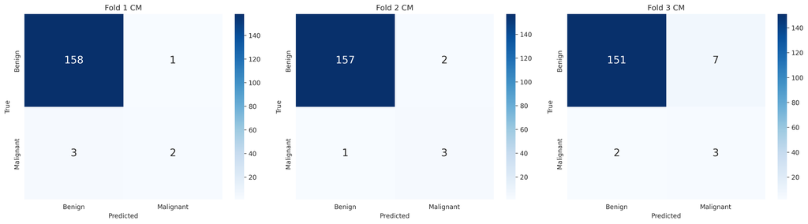

```
Aggregated Confusion Matrix:
TN=466, FP=10, FN=6, TP=8
Overall Accuracy: 0.9673
```

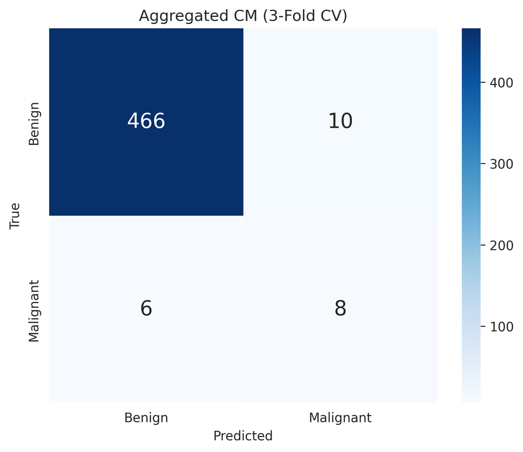

```python
def plot_confusion_matrix(cm, title="Confusion Matrix", save_path=None, ax=None):
    if ax is None:
        fig, ax = plt.subplots(figsize=(6, 5))
        standalone = True
    else:
        standalone = False

    sns.heatmap(cm, annot=True, fmt='d', cmap='Blues',
                xticklabels=['Benign', 'Malignant'],
                yticklabels=['Benign', 'Malignant'],
                annot_kws={'size': 16}, ax=ax)

    ax.set_xlabel('Predicted')
    ax.set_ylabel('True')
    ax.set_title(title)

    if standalone:
        plt.tight_layout()
        if save_path:
            plt.savefig(save_path, dpi=300, bbox_inches='tight')
        plt.show()


# Per-fold confusion matrices
n_folds = len(fold_cms)
fig, axes = plt.subplots(1, n_folds, figsize=(6 * n_folds, 5))
if n_folds == 1:
    axes = [axes]

for i, cm in enumerate(fold_cms):
    plot_confusion_matrix(cm, title=f"Fold {i+1} CM", ax=axes[i])

plt.tight_layout()
plt.savefig(os.path.join(FIGURES_DIR, 'confusion_matrix_per_fold.png'), dpi=300, bbox_inches='tight')
plt.show()

# Aggregated confusion matrix
total_tp = int(df_results['TP'].sum())
total_tn = int(df_results['TN'].sum())
total_fp = int(df_results['FP'].sum())
total_fn = int(df_results['FN'].sum())

cm_aggregated = np.array([[total_tn, total_fp], [total_fn, total_tp]])

print("Aggregated Confusion Matrix:")
print(f"TN={total_tn}, FP={total_fp}, FN={total_fn}, TP={total_tp}")
print(f"Overall Accuracy: {(total_tn + total_tp) / (total_tn + total_fp + total_fn + total_tp):.4f}")

plot_confusion_matrix(cm_aggregated, f"Aggregated CM ({CONFIG['n_splits']}-Fold CV)",
                     save_path=os.path.join(FIGURES_DIR, 'confusion_matrix_aggregated.png'))
```

```python
# Save results
df_results.to_csv(os.path.join(SAVE_DIR, "cv_results.csv"), index=False)
df_summary.to_csv(os.path.join(SAVE_DIR, "cv_summary.csv"), index=False)

print(f"\nFinal Results ({CONFIG['n_splits']}-fold CV):")
print(f"Accuracy:    {avg['Accuracy']:.2%} +/- {std['Accuracy']:.2%}")
print(f"Sensitivity: {avg['Sensitivity']:.2%} +/- {std['Sensitivity']:.2%}")
print(f"Specificity: {avg['Specificity']:.2%} +/- {std['Specificity']:.2%}")
print(f"AUC:         {avg['AUC']:.4f} +/- {std['AUC']:.4f}")
print(f"F1-Score:    {avg['F1-Score']:.4f} +/- {std['F1-Score']:.4f}")
print(f"\nResults saved to: {SAVE_DIR}")
```

```
Final Results (3-fold CV):
Accuracy:    96.73% +/- 1.98%
Sensitivity: 58.33% +/- 17.56%
Specificity: 97.89% +/- 2.04%
AUC:         0.8640 +/- 0.1306
F1-Score:    0.5222 +/- 0.1347

Results saved to: ./paper_results
```